# Part II - (Prosper Loan Explanatory Analysis)

## by (Peter Enning Junior)

## Investigation Overview

> The key insights in the presentation focuses on certain variables/features related to the borrower and how they impact the loans taken out by borrowers. The insights shared transitioned from univarate to bivarate and then multivarate, just like in the analysis of the dataset.For the individual features/variables,I focus on the distribution of Prosper risk score amongst Borrowers, the Distribution of Loan Status,Percentage of Borrowers are HomeOwners and Distribution Stated Montly Income of Borrowers and Loan Term. I then presented on the the relationship between the loan status of borrowers and Monthly Income and the Relationhip between Loan term and Homeowners. The final insight presented was whether stated monthly income of borrower had an effect on Prosper risk score and homeownership. Appropraite color palettes are used for each visualization in the presentation for clear communication of insights.

## Dataset Overview

> The dataset used for this Project was a Prosper Loan Dataset provided by Udacity.The dataset contains loan information of approximately 113,937 loans, with 81 variables/features (categorical and numerical) which reference either loan information or borrower information.

## What are the Prosper Risk Score of Borrowers?

Most of the borrowers(12,256 borrowers) were given a prosper risk score of 4

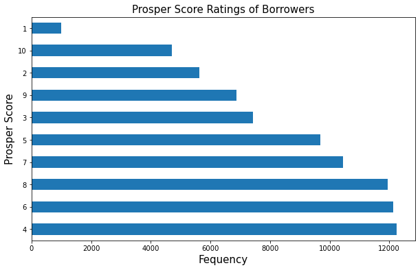

## Distribution of Loan Status

The chart reveals that the "current" loan status is the highest amongst all the other loan statutes. Which means majority of the borrowers are making payments on time.

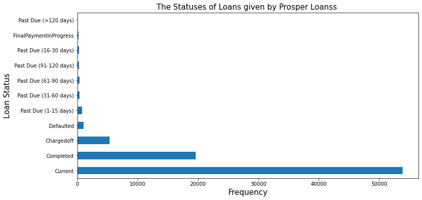

## Distribution Borrowers who are HomeOwners.

It can be clearly seen from the piechart that 53% of borrowers are homeowners compared to 47% of borrowers who aren't

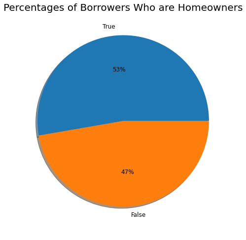

## Distribution Stated Montly Income of Borrowers.

The stated monthly incomes of borrowers shows a right skewed distribution,with most monthly income of borrowers falling between 2,500 and 5,000.

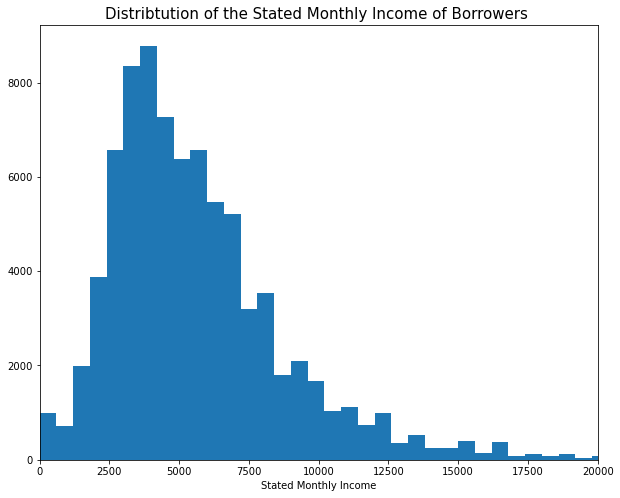

## Distribution Borrowers Loan Terms .

The common loan term preferred by borrowers is 36-months.

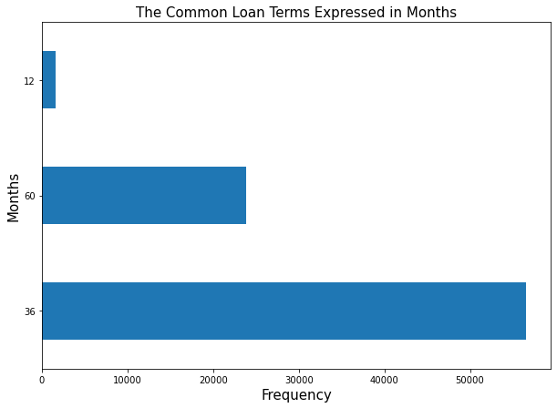

## The relationship between the loan status of borrowers and Monthly Income

The box plot reveals that median salary or typical salary of borrowers who are in the Final Payment Stage of the Loan are higher than borrowers with other loan statuses.

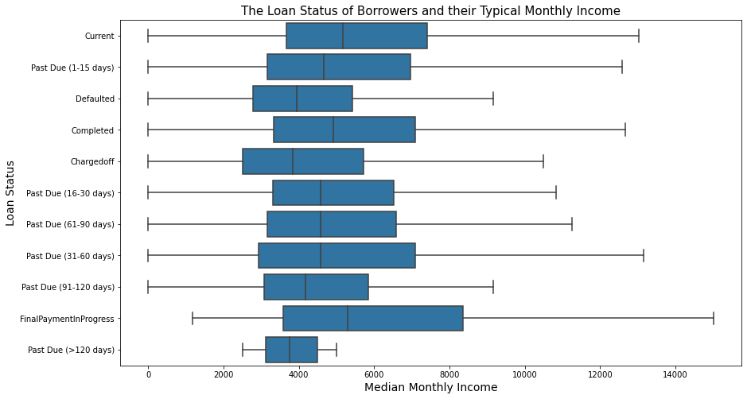

# The Relationhip between Loan term and Homeowners

The Clustered chart shows that for the 3 different types of loan terms, borrowers who are homeowners prefer to take out a 36-month loan term.

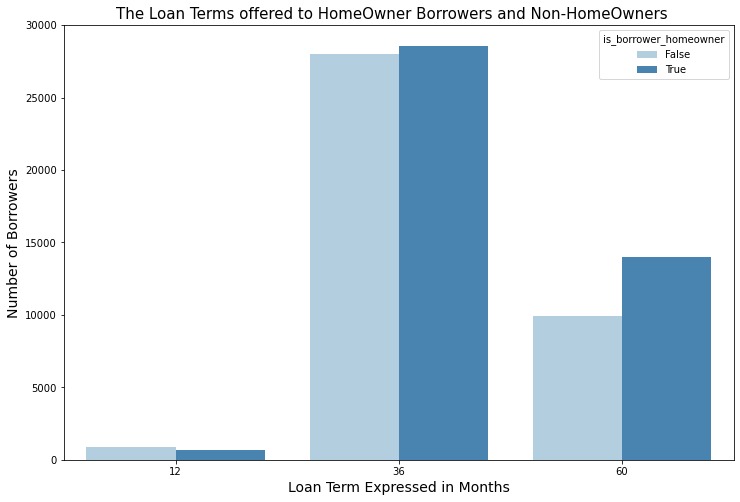

## The Effect of stated monthly income on prosper score and homeownership

The chart reveals an upward trend in monthly income as prosper risk score increases for both homeowners and non Homeowners. With Homeowners earning higher montly salaries than non-homeowners.

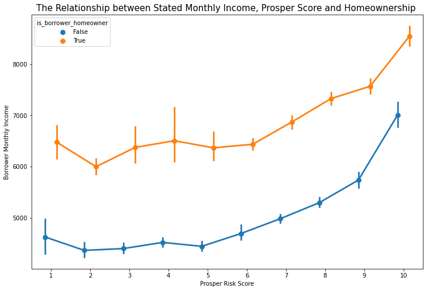